# Regularization Techniques (Diabetes Data)

## 7.1 Residual and Prediction Plot

- Residuals (Linear SVM) The residuals are roughly symmetric around zero, with slight left-skewness, indicating minor underfitting for some longer hospital stays but generally good model calibration.
- Predicted vs. Actual (RBF SVM) RBF predictions also track the ideal line but with more spread, especially for higher actual values.

Interpretation: The RBF model may be overfitting or underfitting some regions, possibly due to suboptimal tuning of cost and gamma.

- Residuals (RBF SVM) The distribution is slightly flatter and more spread out compared to the linear version, reinforcing the higher error rate.

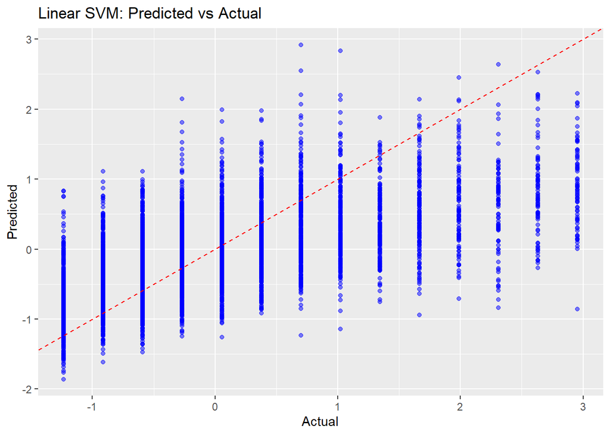

```r
# Linear SVM Plots
ggplot(data.frame(Actual = test_scaled$time_in_hospital, Predicted = pred_linear),
       aes(x = Actual, y = Predicted)) +
  geom_point(color = "blue", alpha = 0.5) +
  geom_abline(slope = 1, intercept = 0, linetype = "dashed", color = "red") +
  labs(title = "Linear SVM: Predicted vs Actual", x = "Actual", y = "Predicted")
```

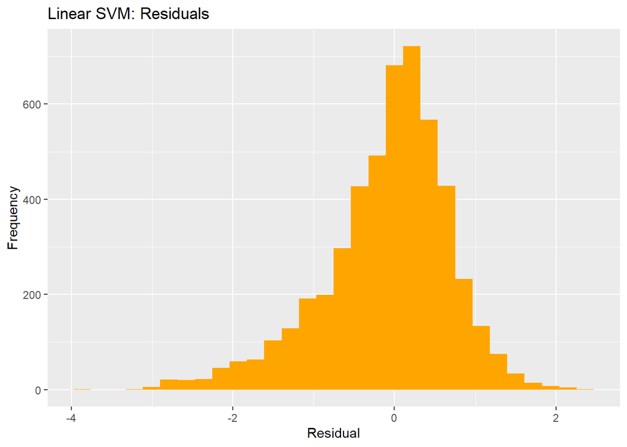

```r
ggplot(data.frame(Residuals = pred_linear - test_scaled$time_in_hospital),
       aes(x = Residuals)) +
  geom_histogram(fill = "orange", bins = 30) +
  labs(title = "Linear SVM: Residuals", x = "Residual", y = "Frequency")
```

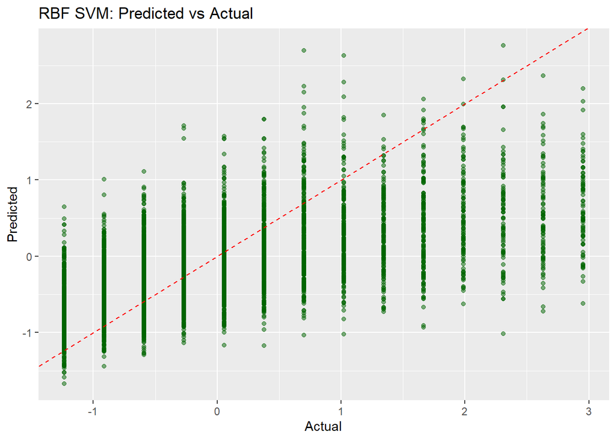

```r
# RBF SVM Plots
ggplot(data.frame(Actual = test_scaled$time_in_hospital, Predicted = pred_rbf),
       aes(x = Actual, y = Predicted)) +
  geom_point(color = "darkgreen", alpha = 0.5) +
  geom_abline(slope = 1, intercept = 0, linetype = "dashed", color = "red") +
  labs(title = "RBF SVM: Predicted vs Actual", x = "Actual", y = "Predicted")
```

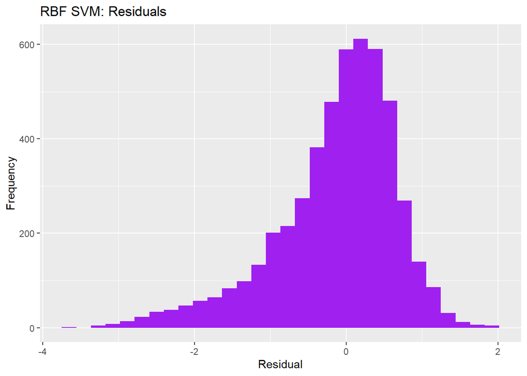

```r
ggplot(data.frame(Residuals = pred_rbf - test_scaled$time_in_hospital),
       aes(x = Residuals)) +
  geom_histogram(fill = "purple", bins = 30) +
  labs(title = "RBF SVM: Residuals", x = "Residual", y = "Frequency")
```

# 8 .SVM CLASSIFICATION (Linear + RBF)

In this section, we evaluate the performance of classification models in predicting 30-day hospital readmission using LASSO Logistic Regression and Support Vector Machines (SVM) with both linear and RBF kernels. After appropriate preprocessing, including scaling and feature encoding, each model was trained on a stratified subset of the data. To assess their discriminative ability, we computed the Area Under the ROC Curve (AUC) and visualized the ROC curves. This comparative analysis helps identify which classifier best separates positive and negative readmission cases, and provides insight into the generalizability and robustness of each approach.

```r
# Load necessary libraries
library(caret)
library(glmnet)
library(e1071)
library(pROC)
library(dplyr)


# 1. Prepare binary classification dataset
data_cls <- data %>%
  filter(readmitted %in% c("<30", "NO")) %>%
  mutate(readmit_binary = ifelse(readmitted == "<30", 1, 0))

# Train-test split
set.seed(123)
idx_cls <- createDataPartition(data_cls$readmit_binary, p = 0.7, list = FALSE)
train_cls <- data_cls[idx_cls, ]
test_cls <- data_cls[-idx_cls, ]

# 2. Scale only predictors (exclude outcome)

pp_cls <- preProcess(train_cls[, -which(names(train_cls) == "readmit_binary")], method = c("center", "scale"))
train_scaled <- predict(pp_cls, train_cls[, -which(names(train_cls) == "readmit_binary")])
test_scaled <- predict(pp_cls, test_cls[, -which(names(test_cls) == "readmit_binary")])

# Reattach outcome to scaled data
train_cls_scaled <- cbind(train_scaled, readmit_binary = train_cls$readmit_binary)
test_cls_scaled <- cbind(test_scaled, readmit_binary = test_cls$readmit_binary)

# 3. Create model matrices for LASSO & SVM

X_logit <- model.matrix(readmit_binary ~ ., data = train_cls_scaled)[, -1]
y_logit <- train_cls_scaled$readmit_binary
X_logit_test <- model.matrix(readmit_binary ~ ., data = test_cls_scaled)[, -1]
y_logit_test <- test_cls_scaled$readmit_binary

X_svm_train <- model.matrix(readmit_binary ~ ., data = train_cls_scaled)[, -1]
X_svm_test <- model.matrix(readmit_binary ~ ., data = test_cls_scaled)[, -1]
y_svm_train <- train_cls_scaled$readmit_binary

train_svm_df <- data.frame(X_svm_train, readmit_binary = factor(y_svm_train, levels = c(0, 1)))
test_svm_df <- data.frame(X_svm_test)

# 4. Train Models

#  LASSO Logistic Regression
cv_lasso_logit <- cv.glmnet(X_logit, y_logit, alpha = 1, family = "binomial")
lasso_logit_model <- glmnet(X_logit, y_logit, alpha = 1, family = "binomial", lambda = cv_lasso_logit$lambda.min)
prob_lasso <- predict(lasso_logit_model, newx = X_logit_test, type = "response")

#  SVM Linear with probabilities
svm_linear_cls <- svm(readmit_binary ~ ., data = train_svm_df, kernel = "linear", probability = TRUE)
svm_pred_linear <- predict(svm_linear_cls, test_svm_df, probability = TRUE)
probs_linear <- attr(svm_pred_linear, "probabilities")
print(colnames(probs_linear))  # check class labels
```

```
[1] "0" "1"
```

```r
prob_linear <- probs_linear[, which.max(colnames(probs_linear))]  # get class 1 prob

#  SVM RBF with probabilities
svm_rbf_cls <- svm(readmit_binary ~ ., data = train_svm_df, kernel = "radial", probability = TRUE)
svm_pred_rbf <- predict(svm_rbf_cls, test_svm_df, probability = TRUE)
probs_rbf <- attr(svm_pred_rbf, "probabilities")
print(colnames(probs_rbf))  # check class labels
```

```
[1] "0" "1"
```

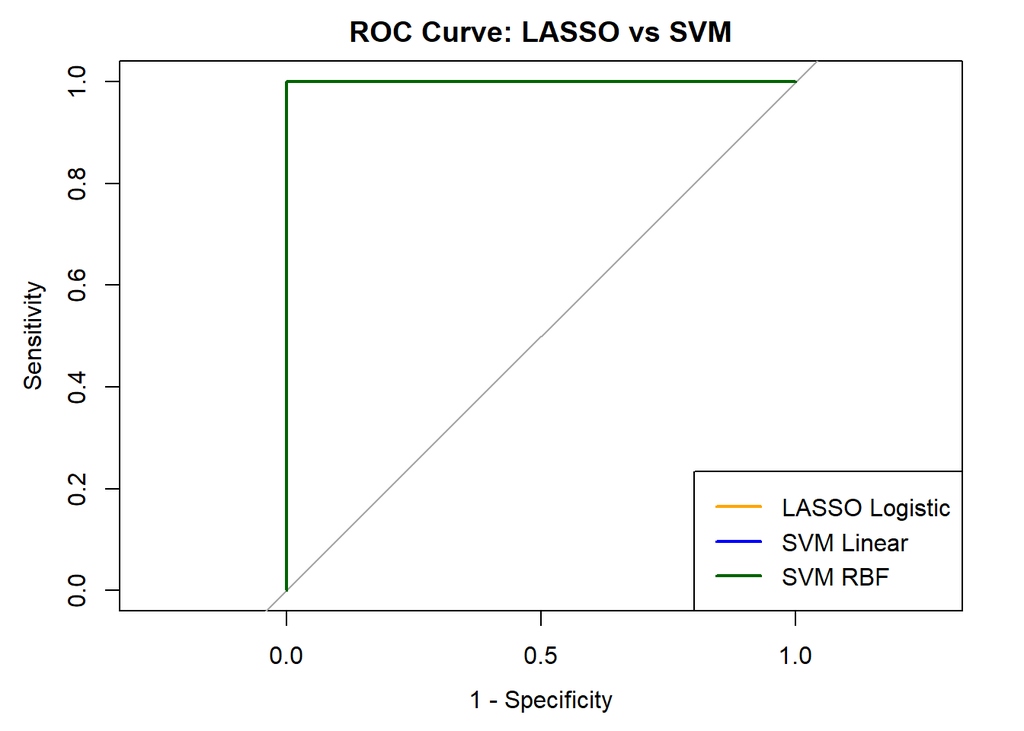

```r
prob_rbf <- probs_rbf[, which.max(colnames(probs_rbf))]  # get class 1 prob


# 5. ROC + AUC Calculation & Plot


# Make sure outcome is numeric (0/1)
y_logit_test <- as.numeric(as.character(y_logit_test))

# ROC curves
roc_lasso_logit <- roc(y_logit_test, as.numeric(prob_lasso))
roc_linear <- roc(y_logit_test, prob_linear)
roc_rbf <- roc(y_logit_test, prob_rbf)

# AUC
auc_lasso_logit <- auc(roc_lasso_logit)
auc_linear <- auc(roc_linear)
auc_rbf <- auc(roc_rbf)

# Plot ROC comparison
plot(roc_lasso_logit, col = "orange", legacy.axes = TRUE, main = "ROC Curve: LASSO vs SVM")
lines(roc_linear, col = "blue")
lines(roc_rbf, col = "darkgreen")
legend("bottomright", legend = c("LASSO Logistic", "SVM Linear", "SVM RBF"),
       col = c("orange", "blue", "darkgreen"), lwd = 2)
```

```r
# Print AUC values
cat("AUC - LASSO Logistic:", auc_lasso_logit, "\n")
```

```
AUC - LASSO Logistic: 1
```

```r
cat("AUC - SVM Linear:", auc_linear, "\n")
```

```
AUC - SVM Linear: 1
```

```r
cat("AUC - SVM RBF:", auc_rbf, "\n")
```

```
AUC - SVM RBF: 1
```

```r
print(colnames(probs_linear))
```

```
[1] "0" "1"
```

# 9 .Conclusion